# Simulation 1

Naomi Altman

May 30, 2016

We start by generating 20 random normals to represent the phenotypic scores of 20 samples and saving them in a variable called *pheno*.

```r
nsamp=20
pheno=rnorm(nsamp)
```

Then we generate 1000 gene expressions. Each has a value for each of the 20 samples. Typically gene expression values are stored in a matrix with genes in the rows and samples in the columns. This matrix is therefore 1000 by 20.

```r
ngene=1000
genes=matrix(rnorm(nsamp*ngene),ncol=nsamp)
```

Next we compute the correlation between the phenotypic score and gene expression. The R *cor* command computes the correlation between the columns of two matrices.

Since the genes are in the rows, we need to transpose the gene expression matrix to compute the correlations.

```r
cors=cor(t(genes),pheno)
```

To visualize the correlations, we draw a histogram. Since we have 1000 correlations, we can have quite a few bins - I selected 50 but R adjusts this based on some algorithm.

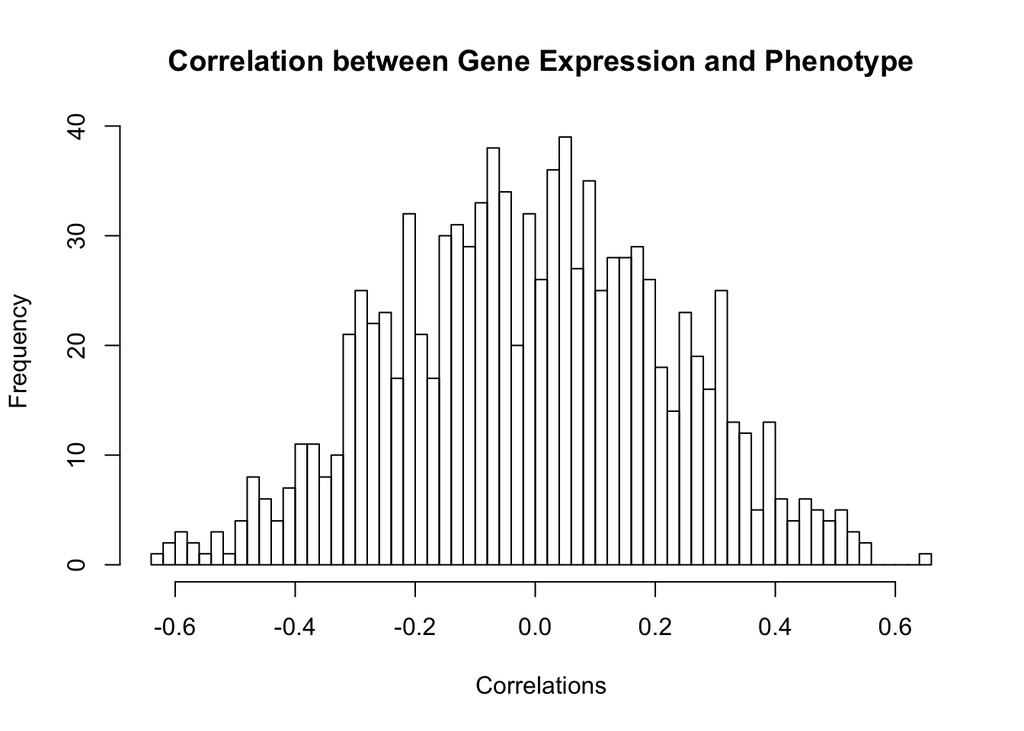

```r
hist(cors,nclass=50,xlab="Correlations",main="Correlation between Gene Expression and Phenotype")
```

```r
nsel=10
selgenes=order(cors,decreasing=FALSE)[1:nsel]
sigGenes=genes[selgenes,]
```

Finally, we do the linear regression on the fitted genes and compute the $R^2$.

```r
regout=lm(pheno~t(sigGenes))
R2=var(fitted(regout))/var(pheno)
anova(regout)
```

```
## Analysis of Variance Table
##
## Response: pheno
##             Df  Sum Sq Mean Sq F value    Pr(>F)
## t(sigGenes) 10 19.6963 1.96963  13.757 0.0002724 ***
## Residuals    9  1.2886 0.14317
## ---
## Signif. codes:  0 '***' 0.001 '**' 0.01 '*' 0.05 '.' 0.1 ' ' 1
```

```r
R2
```

```
## [1] 0.9385954
```